### ESS 575 Models for Ecological Data

#### A Simple Spatial Model for Point Data

#### May 08, 2019

#### Table of Contents

I. Motivation

II. Preliminaries

III. Problem

#### I. Motivation

Most socio-ecological data are spatial. Observations that are close to each other in space are often more similar to one another than observations that are far away. This similarity is not necessarily a problem, but it can cause a problem in our inference. Recall that a fundamental assumption of a statistical inference is that the differences between model predictions and data are independent and identically distributed, which for real-valued observations means
$$\begin{align}
\mu_i&=g(\boldsymbol{\theta},\mathbf{x_i})\\
e_i&=y_i-\mu_i\\
e_{i}&\overset{\text{iid}}{\sim}\text{normal}(0,\sigma^{2}).
\end{align}$$

The problem of spatial autocorrelation is frequently brushed aside without thoughtful treatment. Here, we will learn how to determine if autocorrelation is a problem, and if it is, how to model the spatial structure in the residuals so that our inferences account for it.

We have often said that a primary learning objective of this course is to “learn how to learn.” I almost always learn about something new by posing a simple problem, simulating data relevant to the problem, and writing the math and code needed to solve it. That is what you will do here.

#### II. Preliminaries

Consider the following code for simulating spatially structured data where the data are points with spatial coordinates that could be specified, for example, by utm’s. Study the code relative to the lecture notes on models for point data. This lab will not consider areal data when spatial structure is specified as s network.

Start by loading several libraries, some of which you have not used before. Loading some of these may require downloading packages.

```r
library(stats)
library(rjags)
library(MCMCvis)
library(geoR)
library(MASS)
library(dclone)
library(parallel)
```

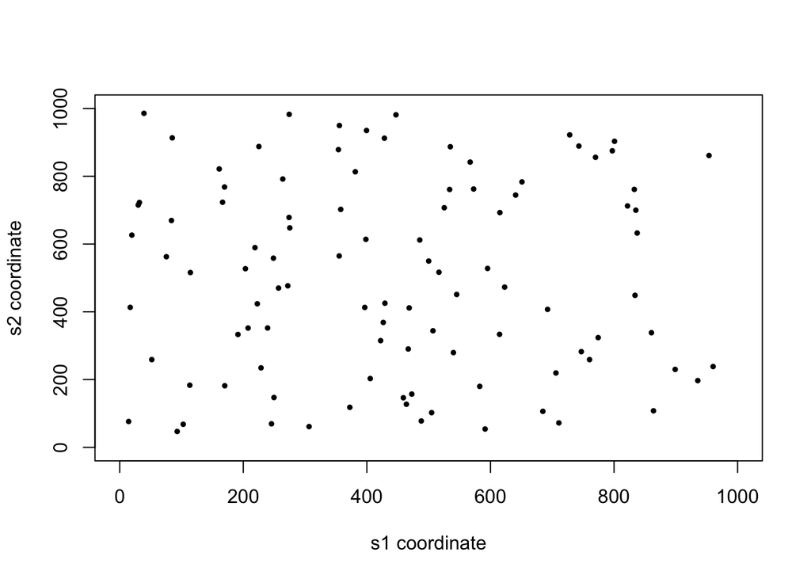

```r
##This function is needed only if you want to run chains in parallel.
run_parallel <- function(){
  out <- clusterEvalQ(cl, {
    library(rjags)
    jm = jags.model(model_file, data = data, inits = initFunc(),
                    n.chains = 1, n.adapt = n.adapt)
    update(jm, n.iter = n.update)
    zmCore = coda.samples(jm, variable.names = variables, n.iter = n.iter, thin = 1)
    return(as.mcmc(zmCore))
    stopCluster(cl)
  })
} # end of run parallel function


####Set some parameter vaues
np = 100  #number of data points
M=matrix(0, nrow = np, ncol=2)  #matrix for holding data and spatial locations
set.seed(10)
limit = 1000 #maximum extent of spatial area (could be any units)
##some parameters
beta0 = 2.3
beta1 = 8
beta2 = -6
#unstructured standard deviation
sigma.u = 1
#spatially structured standard deviation
sigma.s = 5
#a map of points
M[,1] = runif(np,0,limit-1)
M[,2] = runif(np,0,limit-1)

#make some spatially sructured covariates--how this works is not important
X1=-cos(scale(M[,1]-.5)*cos(scale(M[,2])))
X2=scale(M[,1])+scale(M[,2])

#create data frame of spatial coordinates and covariates
M = as.data.frame(cbind(M,X1,X2))
colnames(M) = c("s1", "s2", "x1", "x2")
plot(M$s1,M$s2, xlim=c(0,limit), ylim = c(0,limit), xlab = "s1 coordinate", ylab = "s2 coordinate", pch = 19, cex=.5)
```

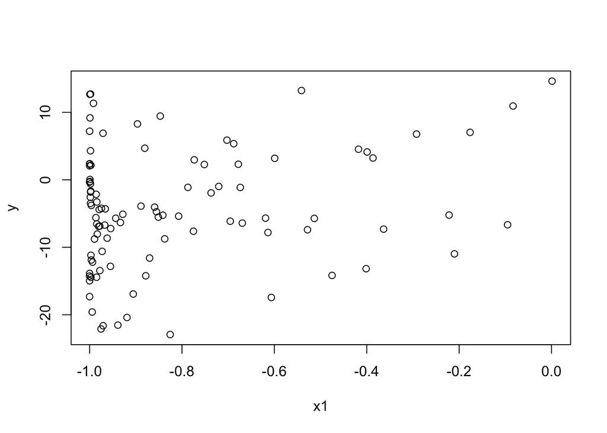

```r
#create response without sptatial structure
M$y = rnorm(np,beta0 + beta1*M$x1+ beta2*M$x2,sigma.u)
plot(M$x1,M$y, ylab= "y", xlab = "x1")
```

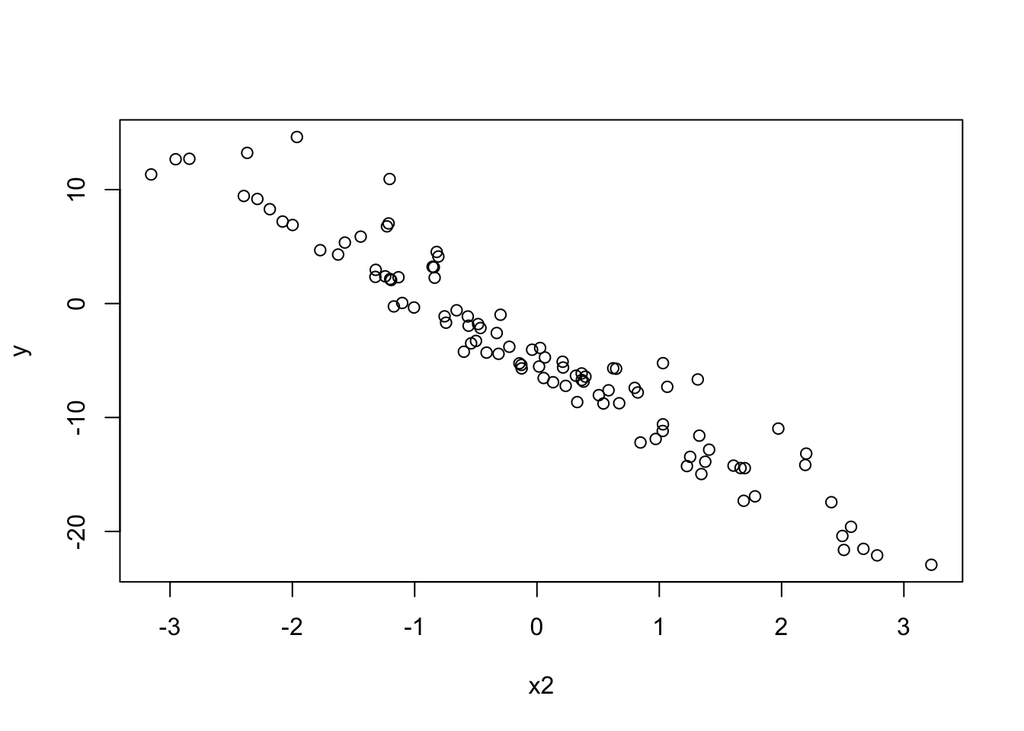

```r
plot(M$x2,M$y, ylab = "y", xlab = "x2")
```

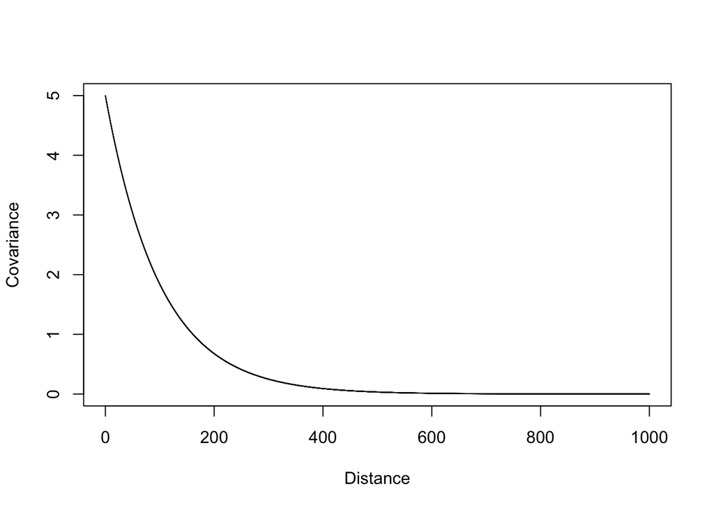

```r
##Create distance matrix and covariance matrix
D = as.matrix(dist(M[,1:2]))
d=seq(0,limit,.001)
phi=100
y.sig = sigma.s*(exp(-d/phi))
plot(d,y.sig, xlim = c(0,1000), typ="l", ylab = "Covariance", xlab = "Distance")
```

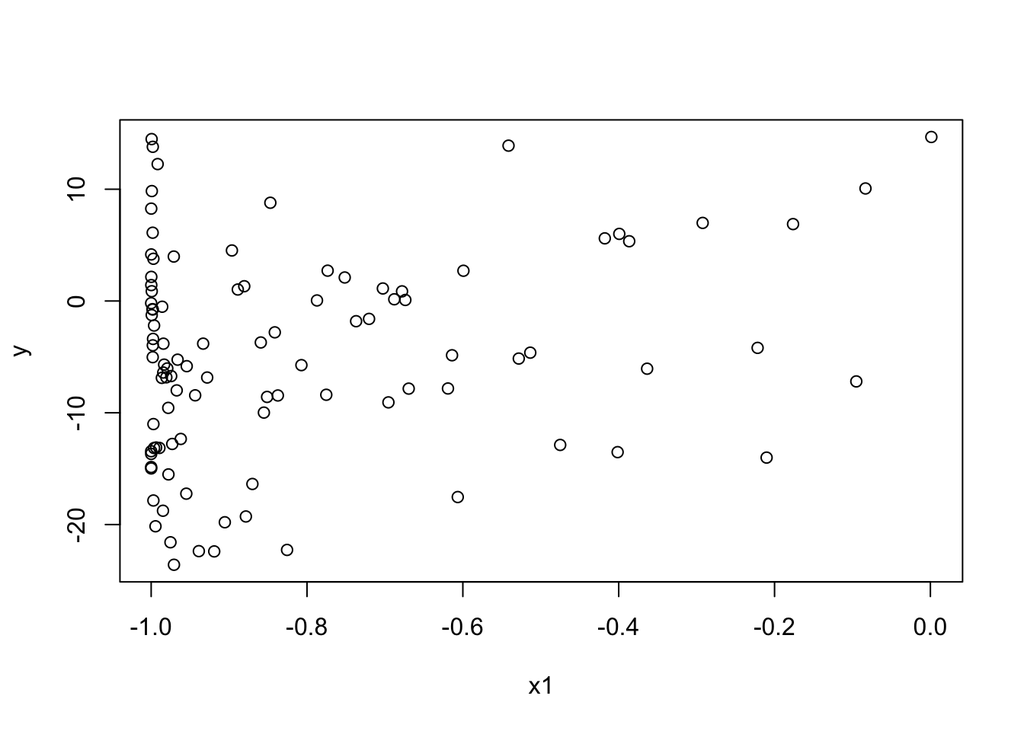

```r
Sigma = sigma.s*exp(-D/phi)

###Create spatially  structured response data by adding 0 centered, spatially structured random variables to the unstructured y.

#Make a vector of draws from a multivariate distribution with first paramter a vector of zeros of length np and second paramter Sigma computed above.
eps=as.vector(mvrnorm(1, rep(0,np),Sigma)) #mnorm with first arg. 1 returns a vector
##Add the zero centered, spatially structred random variable to the y's
M$y.structured = M$y + eps
plot(M$x1,M$y.structured, xlab = "x1", ylab = "y")
```

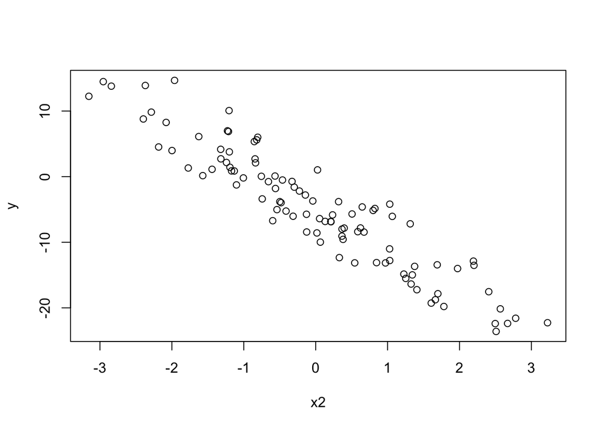

```r
plot(M$x2,M$y.structured, xlab = "x2", ylab = "y")
```

#### An aspatial model for spatially structured data

Now consider an aspatial model

$$\begin{align}
[\boldsymbol{\beta},\sigma\mid\mathbf{y}]&\propto \prod_{i=1}^n\text{normal}(y_i\mid \mathbf{x}_i'\boldsymbol{\beta}, \sigma^2)\\
&\times \prod_{j=0}^2\text{normal}(\beta_j\mid 0,10000)\text{uniform}(\sigma^2\mid 0, 10000)
\end{align}$$

that we fit to the spatially structured data using the following code:

```r
###Fit an unstructured model to the structured data

{ #extra brackets only needed for R markdown
  sink("AspatialJAGS.R")
  cat("
      model{
       for(i in 1:y.np){
         beta[i] ~ dnorm(0,.00001)
}
      sigma ~ dunif(0,50)
      tau <- 1 / sigma^2
       mu = X %*% beta
      for(i in 1:length(y)){
        y[i] ~ dnorm(mu[i], tau)
        e[i] <- y[i] - mu[i]
        y.new[i] ~ dnorm(mu[i], tau)
      }
p.mean = step(mean(y.new) - mean(y))
p.sd = step(sd(y.new) - sd(y))
}
      ",fill=TRUE)
  sink()
}

#create model matrix with column of 1's for intercept
X = cbind(rep(1,nrow(M)), M$x1, M$x2)
data= list( y = M$y.structured, X=X, y.np=ncol(X))
jm = jags.model("AspatialJAGS.R", data=data, n.chains = 3)
update(jm, n.iter = 15000)
zc = coda.samples(jm, n.iter = 10000, variable.names = c("beta", "sigma", "p.mean", "p.sd", "e"))
MCMCsummary(zc,excl = "e", n.eff=TRUE)
```

```
##               mean        sd       2.5%       50%     97.5% Rhat n.eff
## beta[1]  2.4839937 0.7869617  0.9231535  2.483173  4.023364    1  1397
## beta[2]  9.0524012 0.9250696  7.2113653  9.052887 10.867850    1  1380
## beta[3] -6.1610819 0.1661775 -6.4853258 -6.161449 -5.834056    1 31082
## p.mean   0.4971667 0.5000003  0.0000000  0.000000  1.000000    1 30000
## p.sd     0.5094000 0.4999200  0.0000000  1.000000  1.000000    1 25313
## sigma    2.3326394 0.1694021  2.0328547  2.322737  2.689787    1 15971
```

The model converges, but we might want more iterations to increase the effective sample size above 5000 for all quantities of interest. We can see that the model recovers the generating parameters as well as would be expected for a single realization of a stochastic process with a sample size = 100. The model passes posterior predictive checks nicely. What other model checks are needed?

We need to examine the possibility for spatial autocorrelation in the residuals by plotting a semivariogram, a plot of the semivarince as a function of distance between points. Consider the following code and output:

```r
epsilon = MCMCpstr(zc, params = "e", func=median)
epsilon.gd=as.geodata(cbind(M[,1:2],epsilon))
epsilon.v=variog(epsilon.gd, max.dist = max(D/4)) #D/4 standard for plotting variograms
```

```
## variog: computing omnidirectional variogram
```

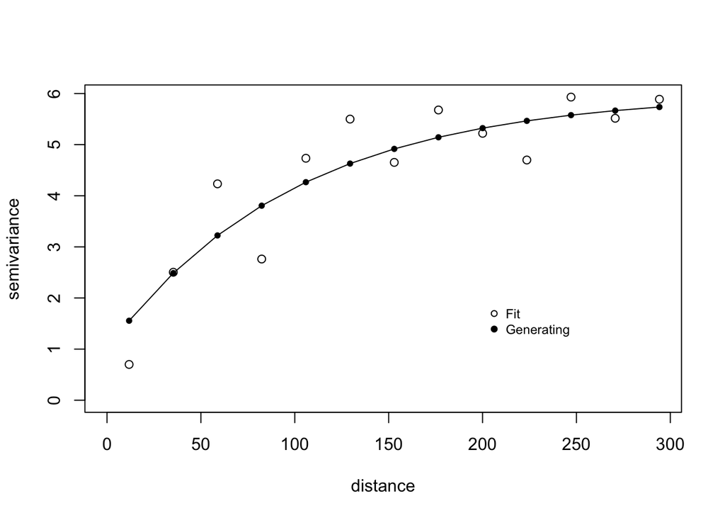

```r
plot(epsilon.v)
semivar.gen=(sigma.s-sigma.s*exp(-epsilon.v$uvec*1/phi)) + sigma.u
lines(epsilon.v$uvec,semivar.gen,type="o",pch=20)
legend(200,2,c("Fit", "Generating"),pch=c(1,19), bty="n", cex=.75)
```

There is clear evidence of spatial autocorrelation in the residuals because semivariance increases as function of distance up to an asymptote at about 200 to 250 (Our units in this example are arbitrary). This means that all of our inferences are excessively optimistic because we are assuming that the residuals are independent.